# exam220705

## Exam 2022-07-05

```python
#first we load some modules
import pandas as pd
import numpy as np
import matplotlib.pyplot as plt
plt.style.use("dark_background")
%matplotlib inline
```

Starting with trying a MDS on the random poisson 'count' data simulating for example genetic data. So lets simulate what we would do in that case. What we expect is no grouping and equally spaced datapoints.

```python
#loading in the data
pois_file = "randompoisson.dat.gz"
pois_df = pd.read_table(pois_file, sep='\s+')
pois_df.head(5)
```

|  | 572 | 752 | 666 | 140 | 2211 | 398 | 23 | 2071 | 1653 | 708 | ... | 2865.1 | 410.8 | 293.9 | 86.6 | 999.1 | 199.11 | 80.5 | 359.3 | 483.4 | 367.11 |
| --- | --- | --- | --- | --- | --- | --- | --- | --- | --- | --- | --- | --- | --- | --- | --- | --- | --- | --- | --- | --- | --- |
| 0 | 588 | 750 | 620 | 166 | 2265 | 402 | 23 | 2152 | 1580 | 744 | ... | 2792 | 467 | 316 | 97 | 994 | 179 | 96 | 370 | 472 | 388 |
| 1 | 580 | 694 | 666 | 166 | 2148 | 348 | 31 | 2141 | 1509 | 699 | ... | 2763 | 459 | 272 | 121 | 914 | 199 | 88 | 400 | 476 | 420 |
| 2 | 600 | 773 | 681 | 132 | 2264 | 351 | 22 | 2146 | 1685 | 713 | ... | 2813 | 415 | 321 | 98 | 985 | 184 | 105 | 376 | 488 | 387 |
| 3 | 576 | 751 | 645 | 121 | 2292 | 368 | 23 | 2050 | 1577 | 689 | ... | 2734 | 426 | 325 | 100 | 1015 | 166 | 102 | 398 | 437 | 414 |
| 4 | 592 | 752 | 673 | 149 | 2243 | 363 | 34 | 2094 | 1624 | 707 | ... | 2820 | 406 | 329 | 75 | 1003 | 178 | 100 | 381 | 491 | 391 |

5 rows × 10000 columns

```python
#Are there empty values?
print(f'Empty values: {pois_df.isna().all().all()}\n')

#Is normalization nessecary?
print(f'Sums of the rows: \n-----------------\
      \n{pois_df.sum(axis=1)}')
```

```
Empty values: False

Sums of the rows:
-----------------
0      10021298
1      10020156
2      10018594
3      10030331
4      10024475
         ...
994    10020623
995    10026609
996    10018085
997    10021065
998    10021562
Length: 999, dtype: int64
```

On first glance the difference is not that big, and normalization of this random data is probably not necessary. But still, if it was real data you would probably do it.

```python
#normalize the data
pois_df = pois_df.subtract(pois_df.mean(axis=1), axis=0)
pois_df.head(5)
```

|  | 572 | 752 | 666 | 140 | 2211 | 398 | 23 | 2071 | 1653 | 708 | ... | 2865.1 | 410.8 | 293.9 | 86.6 | 999.1 | 199.11 | 80.5 | 359.3 | 483.4 | 367.11 |
| --- | --- | --- | --- | --- | --- | --- | --- | --- | --- | --- | --- | --- | --- | --- | --- | --- | --- | --- | --- | --- | --- |
| 0 | -414.1298 | -252.1298 | -382.1298 | -836.1298 | 1262.8702 | -600.1298 | -979.1298 | 1149.8702 | 577.8702 | -258.1298 | ... | 1789.8702 | -535.1298 | -686.1298 | -905.1298 | -8.1298 | -823.1298 | -906.1298 | -632.1298 | -530.1298 | -614.1298 |
| 1 | -422.0156 | -308.0156 | -336.0156 | -836.0156 | 1145.9844 | -654.0156 | -971.0156 | 1138.9844 | 506.9844 | -303.0156 | ... | 1760.9844 | -543.0156 | -730.0156 | -881.0156 | -88.0156 | -803.0156 | -914.0156 | -602.0156 | -526.0156 | -582.0156 |
| 2 | -401.8594 | -228.8594 | -320.8594 | -869.8594 | 1262.1406 | -650.8594 | -979.8594 | 1144.1406 | 683.1406 | -288.8594 | ... | 1811.1406 | -586.8594 | -680.8594 | -903.8594 | -16.8594 | -817.8594 | -896.8594 | -625.8594 | -513.8594 | -614.8594 |
| 3 | -427.0331 | -252.0331 | -358.0331 | -882.0331 | 1288.9669 | -635.0331 | -980.0331 | 1046.9669 | 573.9669 | -314.0331 | ... | 1730.9669 | -577.0331 | -678.0331 | -903.0331 | 11.9669 | -837.0331 | -901.0331 | -605.0331 | -566.0331 | -589.0331 |
| 4 | -410.4475 | -250.4475 | -329.4475 | -853.4475 | 1240.5525 | -639.4475 | -968.4475 | 1091.5525 | 621.5525 | -295.4475 | ... | 1817.5525 | -596.4475 | -673.4475 | -927.4475 | 0.5525 | -824.4475 | -902.4475 | -621.4475 | -511.4475 | -611.4475 |

5 rows × 10000 columns

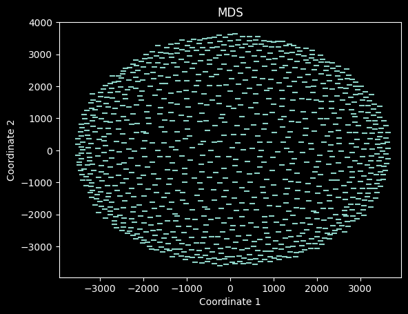

```python
from sklearn.manifold import MDS

mds = MDS(normalized_stress='auto')
scaled_df = mds.fit_transform(pois_df)

CO1 = scaled_df[:,0]
CO2 = scaled_df[:,1]

plt.scatter(CO1,CO2,marker=1)
plt.title("MDS")
plt.xlabel("Coordinate 1")
plt.ylabel("Coordinate 2")
plt.show()
```

The data is grouped in an orderly fashion, no subgroups stand out. It is very uniform and therefore the data seems truly random.

And now the infrared specra of saliva for people tested positive and people that tested negative for covid

```python
# load the data
salv_file = "SourceData2.xlsx"
salv_df = pd.read_excel(salv_file)
salv_df.head(5)
```

|  | ID | Ct | 1300 | 1298 | 1296 | 1294 | 1292 | 1290 | 1288 | 1286 | ... | 818 | 816 | 814 | 812 | 810 | 808 | 806 | 804 | 802 | 800 |
| --- | --- | --- | --- | --- | --- | --- | --- | --- | --- | --- | --- | --- | --- | --- | --- | --- | --- | --- | --- | --- | --- |
| 0 | N1 | NaN | 0.277705 | 0.277532 | 0.277387 | 0.277217 | 0.277042 | 0.276930 | 0.276856 | 0.276737 | ... | 0.242726 | 0.241897 | 0.241107 | 0.240374 | 0.239742 | 0.239234 | 0.238833 | 0.238523 | 0.238314 | 0.238197 |
| 1 | N1 | NaN | 0.251624 | 0.251438 | 0.251268 | 0.251067 | 0.250843 | 0.250645 | 0.250467 | 0.250280 | ... | 0.213427 | 0.212628 | 0.211891 | 0.211234 | 0.210662 | 0.210173 | 0.209763 | 0.209450 | 0.209267 | 0.209202 |
| 2 | N1 | NaN | 0.083310 | 0.083293 | 0.083307 | 0.083338 | 0.083391 | 0.083478 | 0.083585 | 0.083674 | ... | 0.085724 | 0.085260 | 0.084823 | 0.084445 | 0.084137 | 0.083894 | 0.083715 | 0.083602 | 0.083543 | 0.083495 |
| 3 | N2 | NaN | 0.067509 | 0.067070 | 0.066684 | 0.066359 | 0.066106 | 0.065938 | 0.065852 | 0.065828 | ... | 0.055012 | 0.054969 | 0.054902 | 0.054832 | 0.054781 | 0.054767 | 0.054787 | 0.054823 | 0.054857 | 0.054893 |
| 4 | N2 | NaN | 0.129576 | 0.128690 | 0.127912 | 0.127232 | 0.126676 | 0.126306 | 0.126138 | 0.126113 | ... | 0.099128 | 0.098794 | 0.098337 | 0.097886 | 0.097527 | 0.097272 | 0.097091 | 0.096970 | 0.096906 | 0.096881 |

5 rows × 253 columns

```python
#The Ct column has mostly NaN's and is only present for the positives. So lets drop it.
salv_df = salv_df.drop(columns="Ct")
salv_df.head(5)
```

|  | ID | 1300 | 1298 | 1296 | 1294 | 1292 | 1290 | 1288 | 1286 | 1284 | ... | 818 | 816 | 814 | 812 | 810 | 808 | 806 | 804 | 802 | 800 |
| --- | --- | --- | --- | --- | --- | --- | --- | --- | --- | --- | --- | --- | --- | --- | --- | --- | --- | --- | --- | --- | --- |
| 0 | N1 | 0.277705 | 0.277532 | 0.277387 | 0.277217 | 0.277042 | 0.276930 | 0.276856 | 0.276737 | 0.276575 | ... | 0.242726 | 0.241897 | 0.241107 | 0.240374 | 0.239742 | 0.239234 | 0.238833 | 0.238523 | 0.238314 | 0.238197 |
| 1 | N1 | 0.251624 | 0.251438 | 0.251268 | 0.251067 | 0.250843 | 0.250645 | 0.250467 | 0.250280 | 0.250113 | ... | 0.213427 | 0.212628 | 0.211891 | 0.211234 | 0.210662 | 0.210173 | 0.209763 | 0.209450 | 0.209267 | 0.209202 |
| 2 | N1 | 0.083310 | 0.083293 | 0.083307 | 0.083338 | 0.083391 | 0.083478 | 0.083585 | 0.083674 | 0.083739 | ... | 0.085724 | 0.085260 | 0.084823 | 0.084445 | 0.084137 | 0.083894 | 0.083715 | 0.083602 | 0.083543 | 0.083495 |
| 3 | N2 | 0.067509 | 0.067070 | 0.066684 | 0.066359 | 0.066106 | 0.065938 | 0.065852 | 0.065828 | 0.065851 | ... | 0.055012 | 0.054969 | 0.054902 | 0.054832 | 0.054781 | 0.054767 | 0.054787 | 0.054823 | 0.054857 | 0.054893 |
| 4 | N2 | 0.129576 | 0.128690 | 0.127912 | 0.127232 | 0.126676 | 0.126306 | 0.126138 | 0.126113 | 0.126169 | ... | 0.099128 | 0.098794 | 0.098337 | 0.097886 | 0.097527 | 0.097272 | 0.097091 | 0.096970 | 0.096906 | 0.096881 |

5 rows × 252 columns

```python
#are there still nan?

print(salv_df.isna().all().all())
```

```
False
```

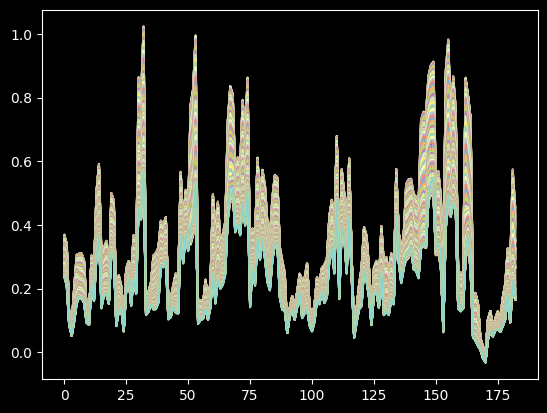

```python
x_range = salv_df.columns[1:]

plt.Figure(figsize=(14,7))
plt.plot(salv_df.iloc[:,1:])
plt.show()
```

```python
from sklearn.preprocessing import MinMaxScaler
from sklearn.preprocessing import StandardScaler

mms = MinMaxScaler(feature_range=(0,1))
stc = StandardScaler()
# now we normalize the data as the absorption of ir spectral light can differ greatly
# there are also some values below zero which is ofcourse not possible
#normalize the data
salv_data = salv_df.iloc[:,1:]
salv_data = salv_data.subtract(salv_data.mean(axis=1), axis=0)
salv_data.iloc[:,:] = mms.fit_transform(salv_data)# every value minimum of 0 maximum of 1
salv_data.iloc[:,:] = stc.fit_transform(salv_data)# every value average of 0 and stdev of 1

salv_df.head()
```

[output not shown]

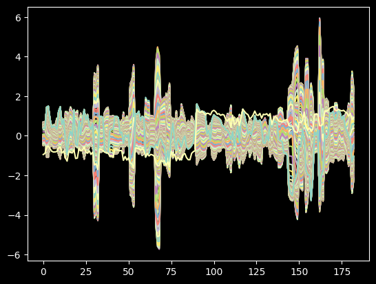

```python
#lets plot the data alvast
x_range = salv_data.columns

plt.plot(salv_data)
plt.show()
```

Now that we have normalized, and created this wonderfull plot lets first perform PCA on the data followed by LDA (because we have two distinct groups).

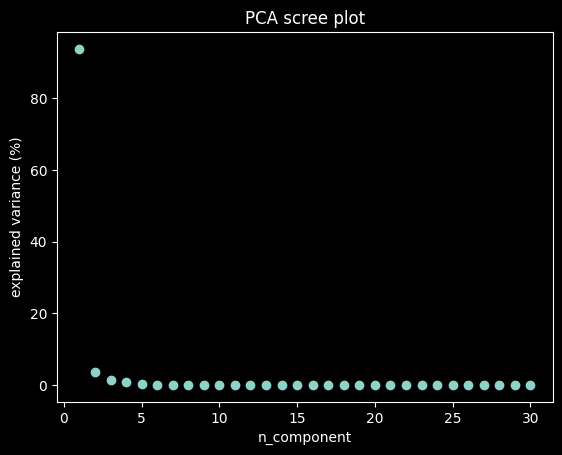

```python
from sklearn.decomposition import PCA

pca = PCA()

# first lets perform a scree plot
pca.fit(salv_df.iloc[:,1:])
pc_ratios = pca.explained_variance_ratio_[:30]
pc_x_range = np.linspace(1,30,30)
plt.scatter(x=pc_x_range, y=pc_ratios*100)
plt.xlabel("n_component")
plt.ylabel("explained variance (%)")
plt.title("PCA scree plot")
plt.show()
```

So a huge portion of the variance can be explained in the first principle component.

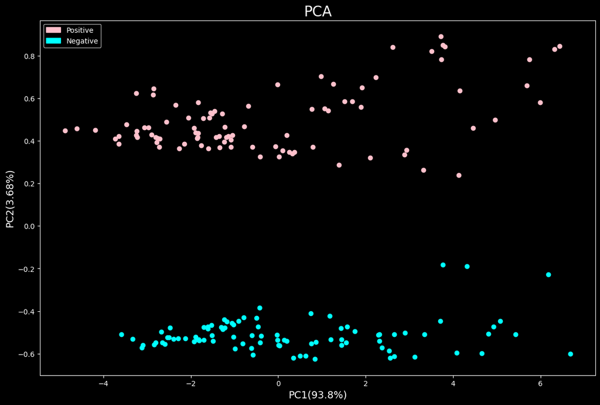

```python
import matplotlib.patches as mpatches

colors = salv_df['ID'].values
color_dict = {'P':'pink','N':'cyan'}

PC1 = pca.fit_transform(salv_df.iloc[:,1:])[:,0]
PC2 = pca.fit_transform(salv_df.iloc[:,1:])[:,1]


fig, ax = plt.subplots(figsize=(14, 9))
for c,p1,p2 in zip(colors,PC1,PC2):
    col = color_dict[c[0]]
    ax.scatter(p1, p2, color=col)
pink_patch = mpatches.Patch(color='pink', label='Positive')
cyan_patch = mpatches.Patch(color='cyan', label='Negative')

ax.set_xlabel(f'PC1({pca.explained_variance_ratio_[0]*100:.3}%)', fontsize=14)
ax.set_ylabel(f'PC2({pca.explained_variance_ratio_[1]*100:.3}%)', fontsize=14)
ax.set_title('PCA', fontsize=20)
ax.legend(handles=[pink_patch,cyan_patch])

plt.show()
```

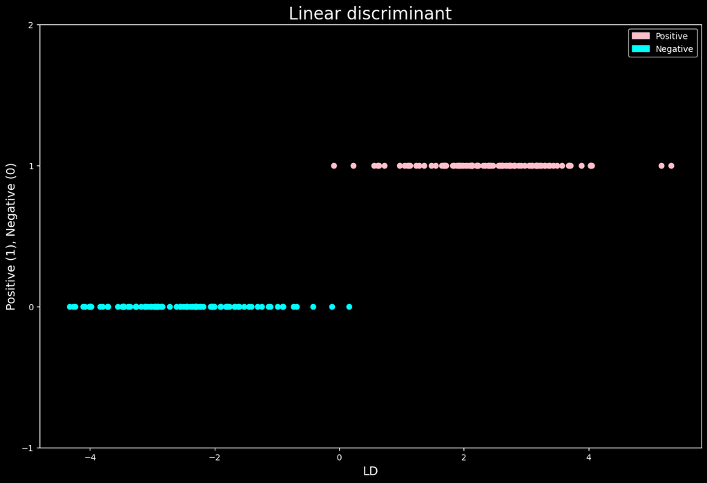

```python
#Lets try the LDA
from sklearn.discriminant_analysis import LinearDiscriminantAnalysis as LDA

salv_df.columns = salv_df.columns.astype(str)

dict_val = {'P':1,'N':0}

salv_df["group"] = [dict_val[val[0]] for val in salv_df["ID"].values]

y = salv_df["group"]

lda = LDA(n_components=1)
LD = lda.fit_transform(salv_df.iloc[:,1:], y)

fig, ax = plt.subplots(figsize=(14, 9))
for c,l1 in zip(colors,LD):
    col = color_dict[c[0]]
    ax.scatter(l1, y=dict_val[c[0]] , color=col)
plt.yticks([-1,0,1,2])
pink_patch = mpatches.Patch(color='pink', label='Positive')
cyan_patch = mpatches.Patch(color='cyan', label='Negative')
ax.set_xlabel('LD', fontsize=14)
ax.set_ylabel('Positive (1), Negative (0)', fontsize=14)
ax.set_title('Linear discriminant', fontsize=20)
ax.legend(handles=[pink_patch,cyan_patch])
plt.show()
```